# Analysis of Foody et al. (2015)

Ian Hussey

16 June, 2026

# Dependencies and functions

```r
# dependencies

library(tidyverse)
library(knitr)
library(kableExtra)
library(janitor)
library(forcats)
library(patchwork)
library(statcheck)
library(readxl)
library(scrutiny)
library(psych)

# create director
dir.create("plots/")
dir.create("tables/")


# functions

#' Print p values to a given number of digits, always rounding up
#' @param p: p value to be rounded
#' @param digits: Number of digits to round to
round_p <- function(p, digits = 3){
  ceiling(as.numeric(p)*10^digits)/10^digits
}


#' Calculate an independent t test from summary statistics
#' @source https://stats.stackexchange.com/q/30450. Improvements made to readability and documentation, added effect sizes.
#' @param m1: the sample 1 mean
#' @param m2: the sample 2 mean
#' @param sd1: the sample 1 SD
#' @param sd2: the sample 2 SD
#' @param n1: the sample 2 sample size
#' @param n2: the sample 2 sample size
#' @param m0: the null value for the difference in means to be tested for. Default is 0.
#' @param equal.variance: whether or not to assume equal variance. Default is FALSE as in the base R t.test function, i.e., a Welch's t-test. Setting to TRUE will produce a Student's t-test.
t_test_from_descriptives <- function(m1, m2, sd1, sd2, n1, n2, m0 = 0, equal.variance = FALSE, alpha = 0.05) {
  require(psych)

  if(equal.variance == FALSE) {
    se <- sqrt( (sd1^2/n1) + (sd2^2/n2) )
    # welch-satterthwaite df
    df <- ( (sd1^2/n1 + sd2^2/n2)^2 )/( (sd1^2/n1)^2/(n1-1) + (sd2^2/n2)^2/(n2-1) )
  } else {
    # pooled standard deviation, scaled by the sample sizes
    se <- sqrt( (1/n1 + 1/n2) * ((n1-1)*sd1^2 + (n2-1)*sd2^2)/(n1+n2-2) )
    df <- n1+n2-2
  }

  t <- (m1 - m2 - m0)/se
  d <- (m1 - m2) / sqrt((sd1^2 + sd2^2)/2)
  d_cis <- psych::cohen.d.ci(d, n2 = n2, n1 = n1, alpha = alpha)

  g <- d * ( 1 - (3 / ((4*(n1 + n2 - 2)) - 1)) ) # https://stats.stackexchange.com/q/434978 by Wolfgang Vichtbauer, creator of metafor package
  g_cis <- psych::cohen.d.ci(g, n2 = n2, n1 = n1, alpha = alpha)

  dat <- data.frame(m1 = m1,
                    sd1 = sd1,
                    n1 = n1,
                    m2 = m2,
                    sd2 = sd2,
                    n2 = n2,
                    mean_difference = m1 - m2,
                    se = se,
                    cohens_d = d,
                    cohens_d_ci_lower = d_cis[1],
                    cohens_d_ci_upper = d_cis[3],
                    hedges_g = g,
                    hedges_g_ci_lower = g_cis[1],
                    hedges_g_ci_upper = g_cis[3],
                    t = t,
                    df = df,
                    p = 2 * pt(-abs(t), df))

  return(dat)
}

round_all_but_p_values <- function(output, digits = 2){
  require(dplyr)

  output |>
    mutate(p = as.character(p)) |>
    mutate_if(is.numeric, janitor::round_half_up, digits = 2)
}

round_half_up_min_decimals <- function(x, digits = 2) {
  sprintf(paste0("%.", digits, "f"), janitor::round_half_up(x, digits = digits))
}
```

# Get data

```r
data_processed <- read_csv("../../../data/processed/foody et al 2015 publication/data_processed.csv")

data_postintervention <- data_processed |>
  filter(timepoint == "postintervention")

data_baseline <- data_processed |>
  filter(timepoint == "baseline")

sample_size <- data_processed |>
  distinct(n) |>
  pull(n)

# check that length of sample size is 1, ie all are identical so this can be used as a numeric
length(sample_size) == 1
```

```
## [1] TRUE
```

# Corrected *p* values for RM-ANOVAs

*p* values extracted from text and corrected via Bonferroni corrections

Foody et al. (2015) reported *p* values for both their 6X4 and 6X2 RM-ANOVAs’ interaction effects that were all non significant:

- Discomfort
  - 6X4 RM-ANOVA interaction effect: F(5, 42)=.58, p=.88, partial eta squared=.07.
  - 6X2 RM-ANOVA interaction effect (just hierarchy vs distinction, no self-vs other): F(5, 42)=.25, p=.94, partial eta squared=.03.
- Anxiety
  - 6X4 RM-ANOVA interaction effect: F(5, 42) =1, p=.47, partial eta squared=.11.
  - 6X2 RM-ANOVA interaction effect (just hierarchy vs distinction, no self-vs other): F(5, 42)=.65, p=.67, partial eta squared=.07.
- Stress
  - 6X4 RM-ANOVA interaction effect: F(5, 42) =1.71, p=.059, partial eta squared=.17
  - 6X2 RM-ANOVA interaction effect (just hierarchy vs distinction, no self-vs other): F(5, 42)=.93, p=.47, partial eta squared=.10.

As such there was no need to correct these Using Bonferroni corrections for multiple testing.

# Reproduce original plot

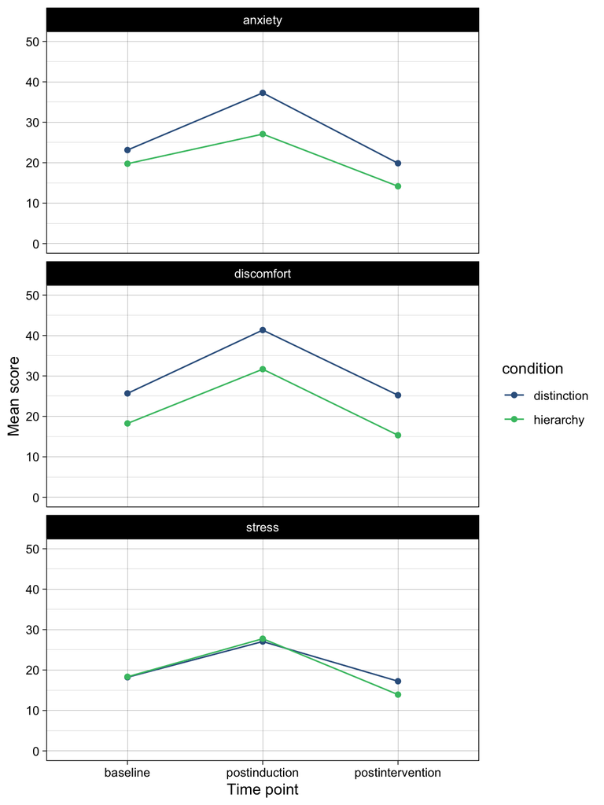

```r
ggplot(data_processed, aes(timepoint, mean, group = condition, color = condition)) +
  geom_line() +
  geom_point() +
  facet_wrap(~ outcome, ncol = 1) +
  scale_color_viridis_d(begin = 0.3, end = 0.7) +
  theme_linedraw() +
  ylim(0, 50) +
  ylab("Mean score") +
  xlab("Time point")
```

# Comparing conditions at postintervention

Using independent Welch’s *t*-tests

## Outcome measures reported in Foody et al. (2015)

Adjusted p values via Bonferroni corrections

```r
es <- data_postintervention |>
  rename(outcome_measure = outcome) |>
  pivot_wider(names_from = condition,
              values_from = c(mean, sd, n)) |>
  group_by(outcome_measure) |>
  do(t_test_from_descriptives(m1 = .$mean_distinction,
                              m2 = .$mean_hierarchy,
                              sd1 = .$sd_distinction,
                              sd2 = .$sd_hierarchy,
                              n1 = .$n_distinction,
                              n2 = .$n_hierarchy,
                              alpha = 0.05)) |> # bonferroni corrections
  ungroup() |>
  mutate(outcome_measure = str_to_sentence(outcome_measure)) |>
  mutate(p_adjusted = p.adjust(p, method = "bonferroni"),
         hedges_g_se = (hedges_g_ci_upper - hedges_g_ci_lower)/(1.96*2)) |>
  mutate(outcome_measure = fct_relevel(outcome_measure, "Stress", "Anxiety", "Discomfort")) |>
  select(outcome_measure,
         m1,
         sd1,
         n1,
         m2,
         sd2,
         n2,
         hedges_g,
         hedges_g_ci_lower,
         hedges_g_ci_upper,
         hedges_g_se,
         t,
         df,
         p,
         p_adjusted)

es |>
  select(outcome_measure,
         m1,
         sd1,
         n1,
         m2,
         sd2,
         n2,
         hedges_g,
         hedges_g_ci_lower,
         hedges_g_ci_upper,
         t,
         df,
         p,
         p_adjusted) |>
  mutate(p = round_p(p),
         p_adjusted = round_p(p_adjusted)) |>
  round_all_but_p_values() |>
  kable() |>
  kable_classic(full_width = FALSE)
```

| outcome_measure | m1 | sd1 | n1 | m2 | sd2 | n2 | hedges_g | hedges_g_ci_lower | hedges_g_ci_upper | t | df | p | p_adjusted |
| --- | --- | --- | --- | --- | --- | --- | --- | --- | --- | --- | --- | --- | --- |
| Anxiety | 19.86 | 24.98 | 12 | 14.17 | 17.50 | 12 | 0.25 | -0.55 | 1.06 | 0.65 | 19.70 | 0.526 | 1.00 |
| Discomfort | 25.23 | 25.91 | 12 | 15.33 | 16.37 | 12 | 0.44 | -0.37 | 1.25 | 1.12 | 18.57 | 0.278 | 0.83 |
| Stress | 17.23 | 17.79 | 12 | 13.92 | 17.82 | 12 | 0.18 | -0.62 | 0.98 | 0.46 | 22.00 | 0.654 | 1.00 |

### Pairwise comparisons of effect sizes

Calculate Z scores for the difference between each pair of Hedges’ *g* effect sizes

```r
z_discomfort_anxiety <-
  (es$hedges_g[es$outcome_measure == "Discomfort"] - es$hedges_g[es$outcome_measure == "Anxiety"]) /
  sqrt(es$hedges_g_se[es$outcome_measure == "Discomfort"]^2 + es$hedges_g_se[es$outcome_measure == "Anxiety"]^2)

z_discomfort_stress <-
  (es$hedges_g[es$outcome_measure == "Discomfort"] - es$hedges_g[es$outcome_measure == "Stress"]) /
  sqrt(es$hedges_g_se[es$outcome_measure == "Discomfort"]^2 + es$hedges_g_se[es$outcome_measure == "Stress"]^2)

z_anxiety_stress <-
  (es$hedges_g[es$outcome_measure == "Anxiety"] - es$hedges_g[es$outcome_measure == "Stress"]) /
  sqrt(es$hedges_g_se[es$outcome_measure == "Anxiety"]^2 + es$hedges_g_se[es$outcome_measure == "Stress"]^2)

p_discomfort_anxiety <- (1-pnorm(abs(z_discomfort_anxiety)))*2
p_discomfort_stress  <- (1-pnorm(abs(z_discomfort_stress)))*2
p_anxiety_stress     <- (1-pnorm(abs(z_anxiety_stress)))*2
```

Difference between outcome variables:

- Discomfort vs. Anxiety $p$ = 0.749
- Discomfort vs. Stress $p$ = 0.653
- Anxiety vs. Stress $p$ = 0.897

## Average scores across the three DVs

```r
es_pooled <-
  bind_rows(
    es,
    t_test_from_descriptives(
      m1 = mean(c(data_postintervention$mean[data_postintervention$outcome == "discomfort" & data_postintervention$condition == "distinction"],
                  data_postintervention$mean[data_postintervention$outcome == "anxiety" & data_postintervention$condition == "distinction"],
                  data_postintervention$mean[data_postintervention$outcome == "stress" & data_postintervention$condition == "distinction"])),
      m2 = mean(c(data_postintervention$mean[data_postintervention$outcome == "discomfort" & data_postintervention$condition == "hierarchy"],
                  data_postintervention$mean[data_postintervention$outcome == "anxiety" & data_postintervention$condition == "hierarchy"],
                  data_postintervention$mean[data_postintervention$outcome == "stress" & data_postintervention$condition == "hierarchy"])),
      sd1 = sqrt((data_postintervention$sd[data_postintervention$outcome == "discomfort" & data_postintervention$condition == "distinction"]^2 +
                    data_postintervention$sd[data_postintervention$outcome == "anxiety" & data_postintervention$condition == "distinction"]^2 +
                    data_postintervention$sd[data_postintervention$outcome == "stress" & data_postintervention$condition == "distinction"]^2)/3),
      sd2 = sqrt((data_postintervention$sd[data_postintervention$outcome == "discomfort" & data_postintervention$condition == "hierarchy"]^2 +
                    data_postintervention$sd[data_postintervention$outcome == "anxiety" & data_postintervention$condition == "hierarchy"]^2 +
                    data_postintervention$sd[data_postintervention$outcome == "stress" & data_postintervention$condition == "hierarchy"]^2)/3),
      n1 = sample_size,
      n2 = sample_size
    ) |>
      mutate(outcome_measure = "Distress (pooled)")
  ) |>
  mutate(outcome_measure = fct_relevel(outcome_measure, "Distress (pooled)", "Stress", "Anxiety", "Discomfort")) |>
  select(outcome_measure,
         m1,
         sd1,
         n1,
         m2,
         sd2,
         n2,
         hedges_g,
         hedges_g_ci_lower,
         hedges_g_ci_upper,
         t,
         df,
         p,
         p_adjusted)
```

## Combined results

```r
data_combined <-
  es_pooled |>
  mutate(color = c("original", "original", "original", "new")) |>
  select(outcome_measure,
         m1,
         sd1,
         n1,
         m2,
         sd2,
         n2,
         hedges_g,
         lower = hedges_g_ci_lower,
         upper = hedges_g_ci_upper,
         t,
         df,
         p,
         p_adj = p_adjusted,
         color)

table_1 <- data_combined |>
  filter(outcome_measure != "Distress (pooled)") |>
  select(-color) |>
  mutate(p = round_p(p),
         p_adj = round_p(p_adj)) |>
  round_all_but_p_values()

write_csv(table_1, "tables/table_1.csv")

table_1 |>
  kable() |>
  kable_classic(full_width = FALSE) |>
  add_header_above(c("", "Hierarchy" = 3, "Distinction" = 3, "", "CI" = 2, "", "", "", ""))
```

| outcome_measure | Hierarchy m1 | Hierarchy sd1 | Hierarchy n1 | Distinction m2 | Distinction sd2 | Distinction n2 | hedges_g | CI lower | CI upper | t | df | p | p_adj |
| --- | --- | --- | --- | --- | --- | --- | --- | --- | --- | --- | --- | --- | --- |
| Anxiety | 19.86 | 24.98 | 12 | 14.17 | 17.50 | 12 | 0.25 | -0.55 | 1.06 | 0.65 | 19.70 | 0.526 | 1.00 |
| Discomfort | 25.23 | 25.91 | 12 | 15.33 | 16.37 | 12 | 0.44 | -0.37 | 1.25 | 1.12 | 18.57 | 0.278 | 0.83 |
| Stress | 17.23 | 17.79 | 12 | 13.92 | 17.82 | 12 | 0.18 | -0.62 | 0.98 | 0.46 | 22.00 | 0.654 | 1.00 |

```r
table_2 <- data_combined |>
  filter(outcome_measure == "Distress (pooled)") |>
  select(-color, -p_adj) |>
  mutate(p = round_p(p)) |>
  round_all_but_p_values()

write_csv(table_2, "tables/table_2.csv")

table_2 |>
  kable() |>
  kable_classic(full_width = FALSE) |>
  add_header_above(c("", "Hierarchy" = 3, "Distinction" = 3, "", "CI" = 2, "", "", ""))
```

| outcome_measure | Hierarchy m1 | Hierarchy sd1 | Hierarchy n1 | Distinction m2 | Distinction sd2 | Distinction n2 | hedges_g | CI lower | CI upper | t | df | p |
| --- | --- | --- | --- | --- | --- | --- | --- | --- | --- | --- | --- | --- |
| Distress (pooled) | 20.77 | 23.18 | 12 | 14.47 | 17.24 | 12 | 0.3 | -0.51 | 1.1 | 0.76 | 20.32 | 0.459 |

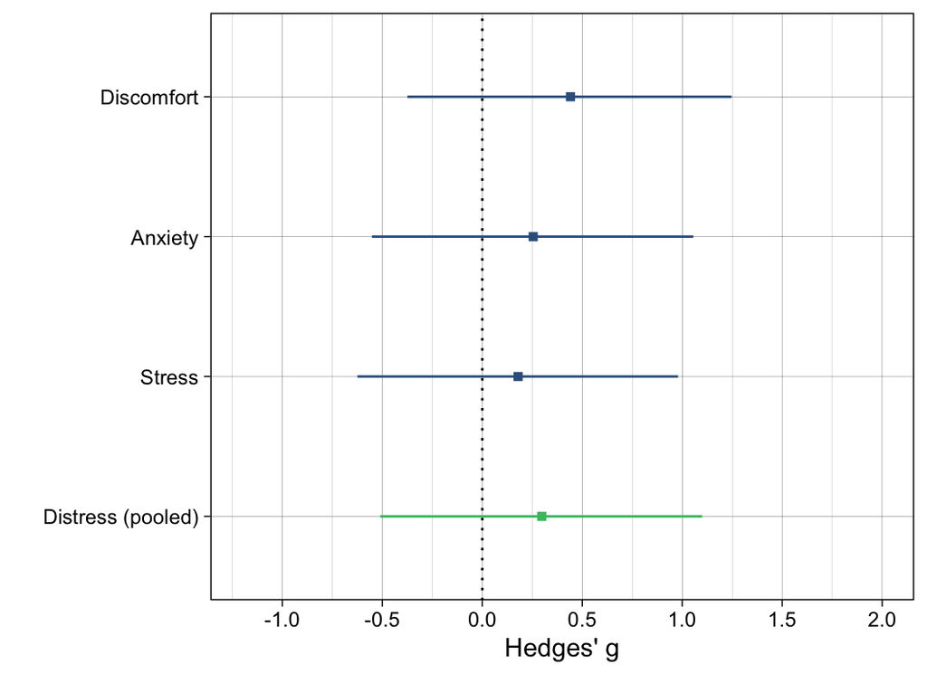

```r
p_combined <-
  ggplot(data_combined, aes(outcome_measure, hedges_g, color = color)) +
  geom_hline(yintercept = 0, linetype = "dotted") +
  geom_point(shape = "square") +
  geom_linerange(aes(ymin = lower, ymax = upper)) +
  scale_y_continuous(breaks = scales::breaks_width(0.5),
                     limits = c(-1.2, 2)) +
  coord_flip() +
  scale_color_viridis_d(begin = 0.3, end = 0.7, direction = -1) +
  theme_linedraw() +
  xlab("") +
  ylab("Hedges' g") +
  theme(legend.position = "none")

p_combined
```

```r
ggplot2::ggsave(filename = "plots/effect size comparisons.pdf",
                plot     = p_combined,
                device   = "pdf",
                width    = 5,
                height   = 4,
                units    = "in")
```